# POLI 110

March 22, 2019

## Correlation to Causation

## Plan for Today:

### **(1) Solutions for Bias**

- adjustment-based
- conditioning
  - what is it?
  - how does it work?
  - assumptions!

## Correlation to Causation

## Solutions to Bias

### **adjustment-based**

- Identify possible **confounding** variables (e.g. \(W, Z, V, U\))
- Measure these variables
- **adjust** correlation of \(X\) and \(Y\) by "**conditioning**" on confounding variables

### **design-based**

- Compare cases that, by assumption, are
  - similar in terms of confounding variables \(W\)/ potential outcomes of \(Y\)
  - exposed to \(X\) in a manner unrelated to \(W\)/potential outcomes of \(Y\)

## Conditioning

A more **general** approach to the comparative method is to **adjust** using:

### **conditioning**

when we observe \(X\) and \(Y\) for multiple cases, we examine the correlation of \(X\) and \(Y\) *within* groups of cases that have the **same values** of confounding variables \(W, Z, \ldots\).

How does conditioning solve confounding?

- By holding \(W\) constant in comparison, can be no relationship between \(W\) and \(X\), \(W\) and \(Y\).
- By definition, no longer confounding

## Conditioning

Sometimes we think about "conditioning" like this:

- conditioning lets us find the correlation between \(X\) and \(Y\), *ceteris parabis*, "all else being equal".

But **all else** does not need to be equal:

- We only need to compare cases that are the same **on confounding variables**
- same on variables that are causally linked to \(X\) and \(Y\)

## Adjustment: Example

### **Sanctuary Cities**

- We saw in toy example, an "unadjusted" correlation between \(Sanctuary\) and \(Crime\) led to confounding and bias
- Conditioning on \(Urban\) solved the confounding, removing the bias

## Adjustment: Example

### **A Real Test** Wong (2017)

Examines crime rates in 2492 US counties. 608 are "Sanctuary" counties.

Researcher matched counties on:

- population
- foreign-born percentage of the population
- percentage of population that is Latino/a
- level of urban development

## Adjustment: Example

### **A Real Test** Wong (2017)

**Compared to similar non-sanctuary counties**

- Crime Rate is 35.5 crimes per 10k *fewer* in sanctuary counties
- Difference has low \(p\) value: unlikely to have happened by chance

Sanctuary policies do not cause an **increase** in crime

## Adjustment: Example

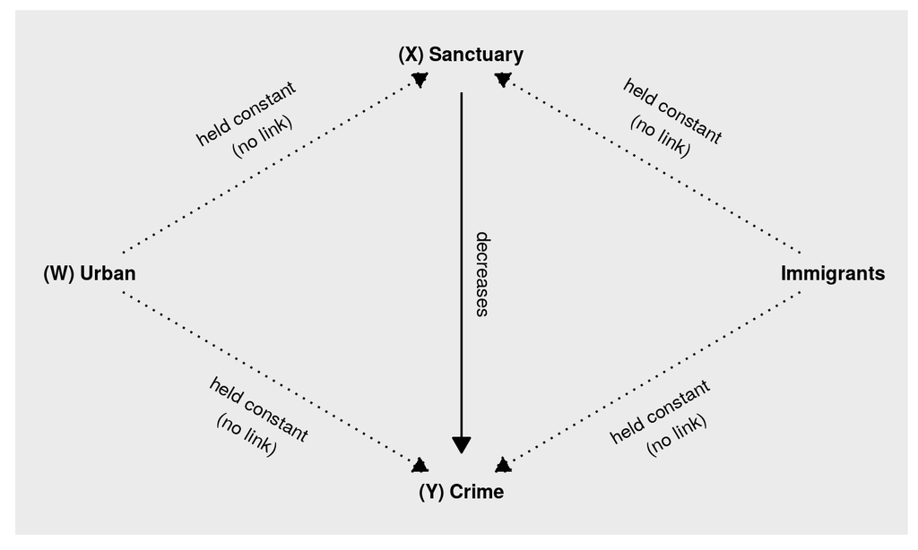

## Adjustment: Example

### **Can you think of any problems here?**

- What else might be related to sanctuary policies?
- economic growth \(\to\) jobs \(\to\) educated citizens \(\to\) sanctuary
- economic growth \(\to\) jobs \(\to\) lower crime

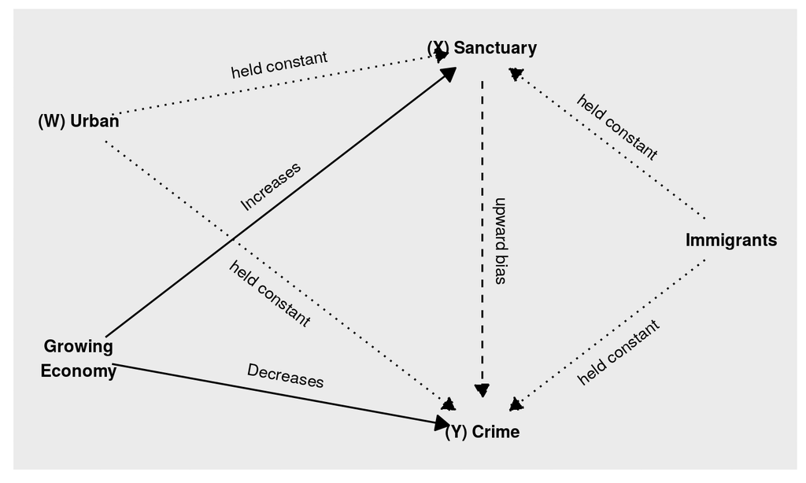

## Adjustment: Assumptions

In order to infer \(X\) causes \(Y\) if \(X,Y\) correlated after adjustment

### **Must Assume**

1. There are **no other confounding variables** (other than the ones you conditioned on)
   - that is, you have conditioned on ALL confounding variables
   - sometimes called 'ignorability assumption': you can ignore other variables

How do we **know** we have found and measured all confounding variables?

## Adjustment: Assumptions

In order to infer \(X\) causes \(Y\) if \(X,Y\) correlated after adjustment

### **Must Assume**

2. **Variables used to condition** relationship between \(X\) and \(Y\) are **measured without error**.
- even **random measurement error** in confounding variables leads conditioning to fail.
- you are no longer comparing like-with-like.

## Adjustment: Limitations

In addition to assumptions: adjustment has **other limitations**

- We are LIMITED by how many variables we can adjust for
  - more variables means: we need more cases
  - less likely we find cases that exactly match
  - relevant confounding variables not adjusted for

### **Side note**

We have shown adjustment that finds identical cases.

- in practice, researcher do not do this; use algorithms that approximate this

## Adjustment: Summary

**Adjustment**: "adjusts" correlation of \(X\) (cause) and$ Y$ (outcome) by **conditioning** on specific, potentially confounding variables

- Examine correlation of \(X,Y\) within groups with same values for confounding variables (**condition**)
- We assume: within these groups, \(X\) is as-if randomly assigned
- Or, we assume: within these groups, nothing other than \(X\) could affect values of \(Y\)

We can infer causality **ONLY IF**:

- no other unobserved/unknown confounding variables
- confounding variables measured without error

## Design-Based Solutions

## Design

**design-based** solutions to confounding:

- **Do not** identify and measure all confounding variables
- Choose a comparison that eliminates bias from many known/unknown measurable/unmeasurable confounding variables

Contrast to **adjustment**:

- focus less on measuring known confounding variables to find comparisons among many cases
- choose fewer cases where confounding is plausibly less or absent

## Design

### **Types of designs:**

Designs using conditioning

- Compare same case over time
- Compare cases known to be similar at same time
- "Differences in Differences"

Designs using random exposure to \(X\)

- experiments
- "natural experiments"

## Design

### **Designs using conditioning**

Choice of comparison **holds many confounding variables constant**

- we condition, not by finding confounding variables and measuring
- we condition by choosing cases known to be similar

Holds constant **many** confounding variables

## Design: Same Case

- Most similar case to a case?
- ITSELF

## Design: Same Case

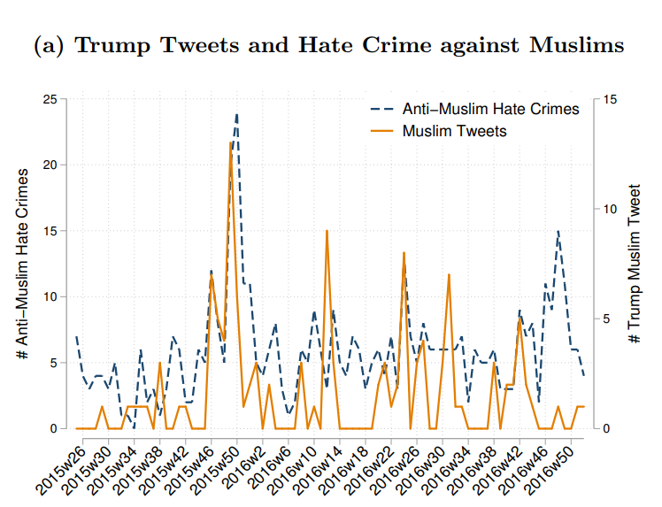